# Integrate_GeneModels_Obiroi

2024-11-04

# Assess confounding gene models from LongRead against established gene models.

## Download and import data from previous gene models and databases

### Import data from previous Gene Models

```r
BRCDK_GTF <- import("Originals/Updated_2024/Obiroi_BRCDK__5_4.gtf.gz")
RefSeq_GTF <- import("Originals/Refseq/Obiroi_RefSeq__5_4_renamed.gtf.gz")
GenBank_GTF <- import("Originals/Genbank/Obiroi_GenBank__5_4_renamed.gtf.gz")
```

### Download additional files from UCSC genome hubs and rename chromosomes.

```r
dir.create("Originals/UCSC_Augustus/",showWarnings = FALSE,recursive = TRUE)
dir.create("Originals/UCSC_EnsGene/",showWarnings = FALSE,recursive = TRUE)
dir.create("Originals/UCSC_RefSeq/",showWarnings = FALSE,recursive = TRUE)
dir.create("Originals/UCSC_XenoRefGene/",showWarnings = FALSE,recursive = TRUE)
dir.create("Originals/UCSC_ChromMap/",showWarnings = FALSE,recursive = TRUE)

download.file("https://hgdownload.soe.ucsc.edu/hubs/GCF/003/672/135/GCF_003672135.1/genes/GCF_003672135.1_Obir_v5.4.augustus.gtf.gz",
       "Originals/UCSC_Augustus/GCF_003672135.1_Obir_v5.4.augustus.gtf.gz")
download.file("https://hgdownload.soe.ucsc.edu/hubs/GCF/003/672/135/GCF_003672135.1/genes/GCF_003672135.1_Obir_v5.4.ensGene.2021_12.gtf.gz",
       "Originals/UCSC_EnsGene/GCF_003672135.1_Obir_v5.4.ensGene.2021_12.gtf.gz")
download.file("https://hgdownload.soe.ucsc.edu/hubs/GCF/003/672/135/GCF_003672135.1/genes/GCF_003672135.1_Obir_v5.4.ncbiRefSeq.gtf.gz",
       "Originals/UCSC_RefSeq/GCF_003672135.1_Obir_v5.4.ncbiRefSeq.gtf.gz")
download.file("https://hgdownload.soe.ucsc.edu/hubs/GCF/003/672/135/GCF_003672135.1/genes/GCF_003672135.1_Obir_v5.4.xenoRefGene.gtf.gz",
       "Originals/UCSC_XenoRefGene/GCF_003672135.1_Obir_v5.4.xenoRefGene.gtf.gz")
download.file("https://hgdownload.soe.ucsc.edu/hubs/GCF/003/672/135/GCF_003672135.1/GCF_003672135.1.chromAlias.txt",
       "Originals/UCSC_ChromMap/GCF_003672135.1.chromAlias.txt")


UCSC_Refseq_GTF <- import("Originals/UCSC_RefSeq/GCF_003672135.1_Obir_v5.4.ncbiRefSeq.gtf.gz")
UCSC_Augustus_GTF <- import("Originals/UCSC_Augustus/GCF_003672135.1_Obir_v5.4.augustus.gtf.gz")
UCSC_EnsGene_GTF <- import("Originals/UCSC_EnsGene/GCF_003672135.1_Obir_v5.4.ensGene.2021_12.gtf.gz")
UCSC_xenoRefGene_GTF <- import("Originals/UCSC_XenoRefGene/GCF_003672135.1_Obir_v5.4.xenoRefGene.gtf.gz")

chr_map <- read.delim("Originals/UCSC_ChromMap/GCF_003672135.1.chromAlias.txt")

UCSC_Refseq_GTF_2 <- renameSeqlevels(UCSC_Refseq_GTF,
               chr_map %>% pull(assembly,name = "X..refseq"))
UCSC_EnsGene_GTF_2 <- renameSeqlevels(UCSC_EnsGene_GTF,
               chr_map %>% pull(assembly,name = "X..refseq"))
UCSC_Augustus_GTF_2 <- renameSeqlevels(UCSC_Augustus_GTF,
               chr_map %>% pull(assembly,name = "X..refseq"))
UCSC_xenoRefGene_GTF_2 <- renameSeqlevels(UCSC_xenoRefGene_GTF,
               chr_map %>% pull(assembly,name = "X..refseq"))
export(UCSC_Refseq_GTF_2,"Originals/UCSC_RefSeq/GCF_003672135.1_Obir_v5.4.ncbiRefSeq_renamed.gtf")
export(UCSC_EnsGene_GTF_2,"Originals/UCSC_EnsGene/GCF_003672135.1_Obir_v5.4.ensGene.2021_12_renamed.gtf")
export(UCSC_Augustus_GTF_2,"Originals/UCSC_Augustus/GCF_003672135.1_Obir_v5.4.augustus_renamed.gtf")
export(UCSC_xenoRefGene_GTF_2,"Originals/UCSC_XenoRefGene/GCF_003672135.1_Obir_v5.4.xenoRefGenerenamed.gtf")
R.utils::gzip("Originals/UCSC_RefSeq/GCF_003672135.1_Obir_v5.4.ncbiRefSeq_renamed.gtf")
R.utils::gzip("Originals/UCSC_EnsGene/GCF_003672135.1_Obir_v5.4.ensGene.2021_12_renamed.gtf")
R.utils::gzip("Originals/UCSC_Augustus/GCF_003672135.1_Obir_v5.4.augustus_renamed.gtf")
R.utils::gzip("Originals/UCSC_XenoRefGene/GCF_003672135.1_Obir_v5.4.xenoRefGenerenamed.gtf")
```

## Import data from Long and short read data

### From Short Read data

```r
ShortStringtie_GTF <- import("Illumina/StringTie_NoGTF//stringtie/stringtie/merged_stringtie.gtf")
ShortStringtieMaleAndFemale_GTF <- import("Illumina/StringTie_MaleAndFemale/stringtie/stringtie/merged_stringtie.gtf")
```

### From Long Read data

```r
LongStringtie_GTF <- import("PacBio/Stringtie/Stringtie_Sample1.gtf")
```

### From mixed Short and Long Read data

```r
LongAndShortStringtie_GTF <- import("PabioAndIllumina/Stringtie/Stringtie_Mixedmode_LongAndShort.gtf")
```

## Assess confounding gene models

### LongRead, ShortRead, BRCDK, RefSeq, GenBank to Txdb objects

```r
BRCDK_txdb <- makeTxDbFromGRanges(BRCDK_GTF)

LongStringtie_GTF <- LongStringtie_GTF[strand(LongStringtie_GTF) != "*"]
ShortStringtie_GTF <- ShortStringtie_GTF[strand(ShortStringtie_GTF) != "*"]

LongStringtie_txdb <- makeTxDbFromGRanges(LongStringtie_GTF)
ShortStringtie_txdb <- makeTxDbFromGRanges(ShortStringtie_GTF)
GenBank_txdb <- makeTxDbFromGRanges(GenBank_GTF)
RefSeq_txdb <- makeTxDbFromGRanges(RefSeq_GTF)
```

### Create exon by gene models

```r
BRCDK_exonsByGene <- exonsBy(BRCDK_txdb,by="gene")
LongStringtie_exonsByGene <- exonsBy(LongStringtie_txdb,by="gene")
ShortStringtie_exonsByGene <- exonsBy(ShortStringtie_txdb,by="gene")
GenBank_exonsByGene <- exonsBy(GenBank_txdb,by="gene")
```

## Assess confounding gene models

### Identify potentially confounding gene models

```r
overlappingGenes <- findOverlaps(BRCDK_exonsByGene,LongStringtie_exonsByGene)
overlappingGenesDF <- as.data.frame(overlappingGenes)
overlappingGenesDF$queryHitsNames <- names(BRCDK_exonsByGene)[overlappingGenesDF$queryHits]
overlappingGenesDF$subjectHitsNames <- names(LongStringtie_exonsByGene)[overlappingGenesDF$subjectHits]

QueryHitFreqFrame <- overlappingGenesDF$queryHits %>%
 table %>%
 as.data.frame() %>%
 set_colnames(c("Query_Hit","Freq"))

QueryMultOverlapTotal <- QueryHitFreqFrame %>%
 filter(Freq > 1) %>%
 nrow

QueryMultiHits <- QueryHitFreqFrame %>%
 filter(Freq > 1) %>%
 pull(Query_Hit)

multi_BRCDK <- names(BRCDK_exonsByGene)[as.numeric(unfactor(QueryMultiHits))]


SubjectHitFreqFrame <- overlappingGenesDF$subjectHits %>%
 table %>%
 as.data.frame() %>%
 set_colnames(c("Subject_Hit","Freq"))

SubjectMultOverlapTotal <- SubjectHitFreqFrame %>%
 filter(Freq > 1) %>%
 nrow

SubMultiHits <- SubjectHitFreqFrame %>%
 filter(Freq > 1) %>%
 pull(Subject_Hit)

multi_longStringtie <- names(LongStringtie_exonsByGene)[SubMultiHits]

noFiltering <- multi_BRCDK

data.frame(Multi_RefSeq_to_Single_LongRead=length(multi_longStringtie),
      Multi_LongRead_to_Single_RefSeq=length(multi_BRCDK)) %>% t %>%
 set_colnames("Counfounding_Gene_Number") %>% datatable()
```

|  | Counfounding_Gene_Number |
| --- | --- |
| Multi_RefSeq_to_Single_LongRead | 774 |
| Multi_LongRead_to_Single_RefSeq | 720 |

#### Assessing manually

# Clean up GTF

## Assess confounded by single exon genes in Long Read data

### Filter single exon longread models and reassess confounding gene models

```r
singleExonGene <- names(LongStringtie_exonsByGene)[lengths(LongStringtie_exonsByGene) == 1]

overlappingGenes <- findOverlaps(BRCDK_exonsByGene,LongStringtie_exonsByGene)
overlappingGenesDF <- as.data.frame(overlappingGenes)
overlappingGenesDF$queryHitsNames <- names(BRCDK_exonsByGene)[overlappingGenesDF$queryHits]
overlappingGenesDF$subjectHitsNames <- names(LongStringtie_exonsByGene)[overlappingGenesDF$subjectHits]
overlappingGenesDF <- overlappingGenesDF[!overlappingGenesDF$subjectHitsNames %in% singleExonGene,]

QueryHitFreqFrame <- overlappingGenesDF$queryHits %>%
 table %>%
 as.data.frame() %>%
 set_colnames(c("Query_Hit","Freq"))

QueryMultOverlapTotal <- QueryHitFreqFrame %>%
 filter(Freq > 1) %>%
 nrow

QueryMultiHits <- QueryHitFreqFrame %>%
 filter(Freq > 1) %>%
 pull(Query_Hit)

multi_BRCDK <- names(BRCDK_exonsByGene)[as.numeric(unfactor(QueryMultiHits))]


SubjectHitFreqFrame <- overlappingGenesDF$subjectHits %>%
 table %>%
 as.data.frame() %>%
 set_colnames(c("Subject_Hit","Freq"))

SubjectMultOverlapTotal <- SubjectHitFreqFrame %>%
 filter(Freq > 1) %>%
 nrow

SubMultiHits <- SubjectHitFreqFrame %>%
 filter(Freq > 1) %>%
 pull(Subject_Hit)

multi_longStringtie <- names(LongStringtie_exonsByGene)[as.numeric(unfactor(SubMultiHits))]
singleExon_Filtering <- multi_BRCDK


data.frame(Multi_RefSeq_to_Single_LongRead=length(multi_longStringtie),
      Multi_LongRead_to_Single_RefSeq=length(multi_BRCDK)) %>% t %>%
 set_colnames("Counfounding_Gene_Number") %>% datatable()
```

|  | Counfounding_Gene_Number |
| --- | --- |
| Multi_RefSeq_to_Single_LongRead | 748 |
| Multi_LongRead_to_Single_RefSeq | 407 |

## Assess gene models against GenBank established gene models

### Identity where Long read and Refseq have confounded gene models but Long read agrees with GenBank

```r
overlappingGenesDF_MultiHits <- overlappingGenesDF[overlappingGenesDF$queryHitsNames %in% multi_BRCDK,]
unique_BRCDK_MultiHits <- overlappingGenesDF_MultiHits %>% pull(queryHitsNames) %>% unique

# GenBank_exonsByGene_noSingle <- GenBank_exonsByGene[lengths(GenBank_exonsByGene) > 1]
filterVec <- vector("logical",length = length(unique_BRCDK_MultiHits))
for(i in 1:length(unique_BRCDK_MultiHits)){
 message(i)
 StringTie_Genes_Temp <- overlappingGenesDF_MultiHits[overlappingGenesDF_MultiHits$queryHitsNames %in%
                 unique_BRCDK_MultiHits[i],
                "subjectHitsNames"]
 OverlapTableTemp <- as.data.frame(findOverlaps(LongStringtie_exonsByGene[StringTie_Genes_Temp],GenBank_exonsByGene))
 if(any(duplicated(OverlapTableTemp$queryHits))){
  filterVec[i] <- FALSE
 }else if(any(duplicated(OverlapTableTemp$subjectHits))){
  filterVec[i] <- FALSE
 }else{
  filterVec[i] <- TRUE
 }
}
names(filterVec) <- unique_BRCDK_MultiHits
```

### Apply Genbank filter and assess confounding gene models

```r
singleExonGene <- names(LongStringtie_exonsByGene)[lengths(LongStringtie_exonsByGene) == 1]

overlappingGenes <- findOverlaps(BRCDK_exonsByGene,LongStringtie_exonsByGene)
overlappingGenesDF <- as.data.frame(overlappingGenes)
overlappingGenesDF$queryHitsNames <- names(BRCDK_exonsByGene)[overlappingGenesDF$queryHits]
overlappingGenesDF$subjectHitsNames <- names(LongStringtie_exonsByGene)[overlappingGenesDF$subjectHits]
overlappingGenesDF <- overlappingGenesDF[!overlappingGenesDF$subjectHitsNames %in% singleExonGene,]
overlappingGenesDF <- overlappingGenesDF[!overlappingGenesDF$queryHitsNames %in% names(filterVec[filterVec])
,]


QueryHitFreqFrame <- overlappingGenesDF$queryHits %>%
 table %>%
 as.data.frame() %>%
 set_colnames(c("Query_Hit","Freq"))

QueryMultOverlapTotal <- QueryHitFreqFrame %>%
 filter(Freq > 1) %>%
 nrow

QueryMultiHits <- QueryHitFreqFrame %>%
 filter(Freq > 1) %>%
 pull(Query_Hit)

multi_BRCDK <- names(BRCDK_exonsByGene)[as.numeric(unfactor(QueryMultiHits))]


SubjectHitFreqFrame <- overlappingGenesDF$subjectHits %>%
 table %>%
 as.data.frame() %>%
 set_colnames(c("Subject_Hit","Freq"))

SubjectMultOverlapTotal <- SubjectHitFreqFrame %>%
 filter(Freq > 1) %>%
 nrow

SubMultiHits <- SubjectHitFreqFrame %>%
 filter(Freq > 1) %>%
 pull(Subject_Hit)

multi_longStringtie <- names(LongStringtie_exonsByGene)[as.numeric(unfactor(SubMultiHits))]

GenbankFiltering <- multi_BRCDK

data.frame(Multi_RefSeq_to_Single_LongRead=length(multi_longStringtie),
      Multi_LongRead_to_Single_RefSeq=length(multi_BRCDK)) %>% t %>%
 set_colnames("Counfounding_Gene_Number") %>% datatable()
```

|  | Counfounding_Gene_Number |
| --- | --- |
| Multi_RefSeq_to_Single_LongRead | 654 |
| Multi_LongRead_to_Single_RefSeq | 179 |

#### Assess manually

## Assess and fix gene models confounded within Refseq Annotation.

### Find and fix transcripts in genes which overlap other genes within the Refseq annotation.

```r
BRCDK_exonsByTranscript <- exonsBy(BRCDK_txdb,by="tx",use.names=TRUE)
BRCDK_GTF_GeneToTranscript <- BRCDK_GTF %>% mcols %>%
 as.data.frame() %>%
 dplyr::select(gene_id,transcript_id) %>%
 distinct()

selfOverlaps <- findOverlaps(BRCDK_exonsByTranscript,BRCDK_exonsByTranscript)
temp_selfOverlaps <- as.data.frame(selfOverlaps)

temp_selfOverlaps$queryHitsNames <- names(BRCDK_exonsByTranscript)[temp_selfOverlaps$queryHits]
temp_selfOverlaps$subjectHitsNames <- names(BRCDK_exonsByTranscript)[temp_selfOverlaps$subjectHits]

temp_selfOverlaps$queryHitsGeneNames <- BRCDK_GTF_GeneToTranscript$gene_id[match(temp_selfOverlaps$queryHitsNames,
                       BRCDK_GTF_GeneToTranscript$transcript_id)]

temp_selfOverlaps$subjectHitsGeneNames <- BRCDK_GTF_GeneToTranscript$gene_id[match(temp_selfOverlaps$subjectHitsNames,
                       BRCDK_GTF_GeneToTranscript$transcript_id)]

temp_selfOverlaps$subjectHitsGeneNames[is.na(temp_selfOverlaps$subjectHitsGeneNames)] <- temp_selfOverlaps$subjectHitsNames[is.na(temp_selfOverlaps$subjectHitsGeneNames)]

temp_selfOverlaps$queryHitsGeneNames[is.na(temp_selfOverlaps$queryHitsGeneNames)] <- temp_selfOverlaps$queryHitsNames[is.na(temp_selfOverlaps$queryHitsGeneNames)]


temp_selfOverlaps <- temp_selfOverlaps[temp_selfOverlaps$queryHitsGeneNames != temp_selfOverlaps$subjectHitsGeneNames,]
nrow(temp_selfOverlaps)
```

```
## [1] 1144
```

```r
allSelfOverlapGenes <- temp_selfOverlaps[,3] %>% unique

datatable(
 data.frame(Genes_Overlapping_Other_Genes_Within_Refseq_Models=temp_selfOverlaps[,5] %>% unique %>% length())
)
```

|  | Genes_Overlapping_Other_Genes_Within_Refseq_Models |
| --- | --- |
| 1 | 554 |

```r
if(!file.exists("RObjects/BRCDK_NoGeneModelOverlap.gtf")){



while(nrow(temp_selfOverlaps) > 0){
message("Overlapping transcripts - ",nrow(temp_selfOverlaps))
 loop <- 1
# XM_026973633.1 1372
updatedGene <- GRangesList()
for(i in 1:nrow(temp_selfOverlaps)){
 geneA <- temp_selfOverlaps[i,3]
 geneB <- temp_selfOverlaps[i,4]
 exons_geneA <- BRCDK_exonsByTranscript[geneA]
 exons_geneB <- BRCDK_exonsByTranscript[geneB]
 if(all(strand(exons_geneA) == "+")){
  if(start(exons_geneA[[1]][1]) < start(exons_geneB[[1]][1])){
   proceedingGene <- exons_geneA
   followingGene <- exons_geneB
  }else{
   proceedingGene <- exons_geneB
   followingGene <- exons_geneA
  }
  rangeToRestrict <- c(start(proceedingGene[[1]][1]),start(followingGene[[1]][1])-20)
  updatedGene <- c(updatedGene,restrict(proceedingGene[1],start = rangeToRestrict[1],end=rangeToRestrict[2]))
   # print("+")
 }else if(all(strand(exons_geneA) == "-")){
  if(end(exons_geneA[[1]][length(exons_geneA[[1]])]) > end(exons_geneB[[1]][length(exons_geneB[[1]])])){
   proceedingGene <- exons_geneA
   followingGene <- exons_geneB
  }else{
   proceedingGene <- exons_geneB
   followingGene <- exons_geneA
  }
  rangeToRestrict <- c(end(followingGene[[1]][1])+20,end(proceedingGene[[1]][1]))
  updatedGene <- c(updatedGene,restrict(proceedingGene[1],start = rangeToRestrict[1],end=rangeToRestrict[2]))
   # print("-")
 }
 if(i %% 100 == 0)message(loop,":",i)
}

BRCDK_exonsByTranscript[names(updatedGene)] <- updatedGene


selfOverlaps <- findOverlaps(BRCDK_exonsByTranscript,BRCDK_exonsByTranscript)
temp_selfOverlaps <- as.data.frame(selfOverlaps)

temp_selfOverlaps$queryHitsNames <- names(BRCDK_exonsByTranscript)[temp_selfOverlaps$queryHits]
temp_selfOverlaps$subjectHitsNames <- names(BRCDK_exonsByTranscript)[temp_selfOverlaps$subjectHits]

temp_selfOverlaps$queryHitsGeneNames <- BRCDK_GTF_GeneToTranscript$gene_id[match(temp_selfOverlaps$queryHitsNames,
                       BRCDK_GTF_GeneToTranscript$transcript_id)]

temp_selfOverlaps$subjectHitsGeneNames <- BRCDK_GTF_GeneToTranscript$gene_id[match(temp_selfOverlaps$subjectHitsNames,
                       BRCDK_GTF_GeneToTranscript$transcript_id)]

temp_selfOverlaps$subjectHitsGeneNames[is.na(temp_selfOverlaps$subjectHitsGeneNames)] <- temp_selfOverlaps$subjectHitsNames[is.na(temp_selfOverlaps$subjectHitsGeneNames)]

temp_selfOverlaps$queryHitsGeneNames[is.na(temp_selfOverlaps$queryHitsGeneNames)] <- temp_selfOverlaps$queryHitsNames[is.na(temp_selfOverlaps$queryHitsGeneNames)]


temp_selfOverlaps <- temp_selfOverlaps[temp_selfOverlaps$queryHitsGeneNames != temp_selfOverlaps$subjectHitsGeneNames,]
loop <- loop+1

}
temp <- unlist(BRCDK_exonsByTranscript)
df_temp <- data.frame(source="StringTie_curated",
             type="exon",
             score=NA,phase=NA,
             gene_id=BRCDK_GTF_GeneToTranscript$gene_id[
              match(names(temp),
                       BRCDK_GTF_GeneToTranscript$transcript_id)
              ],
             transcript_id=names(temp))

df_temp$gene_id[is.na(df_temp$gene_id)] <- df_temp$transcript_id[is.na(df_temp$gene_id)]
mcols(temp) <- df_temp
class(temp$phase) <- "integer"
rtracklayer::export(temp[temp$transcript_id %in% allSelfOverlapGenes,],con="BRCDK_NoGeneModelOverlap.gtf")
rtracklayer::export(temp,con="RObjects/BRCDK_NoGeneModelOverlapFull.gtf")
saveRDS(temp,"RObjects/BRCDK_NoGeneModelOverlapFull.RDS")
}

# BRCDK_GTF <- import("BRCDK_NoGeneModelOverlapFull.gtf")
BRCDK_GTF <- readRDS("RObjects/BRCDK_NoGeneModelOverlapFull.RDS")
BRCDK_txdb <- makeTxDbFromGRanges(BRCDK_GTF)
BRCDK_exonsByGene <- exonsBy(BRCDK_txdb,by = "gene")
selfOverlaps <- findOverlaps(BRCDK_exonsByGene,BRCDK_exonsByGene)
temp_selfOverlaps <- as.data.frame(selfOverlaps)

temp_selfOverlaps$queryHitsNames <- names(BRCDK_exonsByGene)[temp_selfOverlaps$queryHits]
temp_selfOverlaps$subjectHitsNames <- names(BRCDK_exonsByGene)[temp_selfOverlaps$subjectHits]


temp_selfOverlaps <- temp_selfOverlaps[temp_selfOverlaps$queryHits != temp_selfOverlaps$subjectHits,]
#nrow(temp_selfOverlaps)
```

### Apply RefSeq self-overlap filter and then assess confounding gene models between LongRead and RefSeq.

```r
singleExonGene <- names(LongStringtie_exonsByGene)[lengths(LongStringtie_exonsByGene) == 1]

# BRCDK_exonsByGene[names(updatedGene)] <- updatedGene
overlappingGenes <- findOverlaps(BRCDK_exonsByGene,LongStringtie_exonsByGene)
overlappingGenesDF <- as.data.frame(overlappingGenes)
overlappingGenesDF$queryHitsNames <- names(BRCDK_exonsByGene)[overlappingGenesDF$queryHits]
overlappingGenesDF$subjectHitsNames <- names(LongStringtie_exonsByGene)[overlappingGenesDF$subjectHits]
overlappingGenesDF <- overlappingGenesDF[!overlappingGenesDF$subjectHitsNames %in% singleExonGene,]
overlappingGenesDF <- overlappingGenesDF[!overlappingGenesDF$queryHitsNames %in% names(filterVec[filterVec])
,]


QueryHitFreqFrame <- overlappingGenesDF$queryHits %>%
 table %>%
 as.data.frame() %>%
 set_colnames(c("Query_Hit","Freq"))

QueryMultOverlapTotal <- QueryHitFreqFrame %>%
 filter(Freq > 1) %>%
 nrow

QueryMultiHits <- QueryHitFreqFrame %>%
 filter(Freq > 1) %>%
 pull(Query_Hit)

multi_BRCDK <- names(BRCDK_exonsByGene)[as.numeric(unfactor(QueryMultiHits))]


SubjectHitFreqFrame <- overlappingGenesDF$subjectHits %>%
 table %>%
 as.data.frame() %>%
 set_colnames(c("Subject_Hit","Freq"))

SubjectMultOverlapTotal <- SubjectHitFreqFrame %>%
 filter(Freq > 1) %>%
 nrow

SubMultiHits <- SubjectHitFreqFrame %>%
 filter(Freq > 1) %>%
 pull(Subject_Hit)

multi_longStringtie <- names(LongStringtie_exonsByGene)[as.numeric(unfactor(SubMultiHits))]

overlappingRefSeqFiltering <- multi_BRCDK

data.frame(Multi_RefSeq_to_Single_LongRead=length(multi_longStringtie),
      Multi_LongRead_to_Single_RefSeq=length(multi_BRCDK)) %>% t %>%
  set_colnames("Counfounding_Gene_Number") %>% datatable()
```

|  | Counfounding_Gene_Number |
| --- | --- |
| Multi_RefSeq_to_Single_LongRead | 618 |
| Multi_LongRead_to_Single_RefSeq | 168 |

#### Manually assess

## Use agreement between long read and short read models to evaluate gene models vs RefSeq

### Identity where Long read and Refseq have confounded gene models but Long read agrees with Short Read.

```r
overlappingGenesDF_MultiHits <- overlappingGenesDF[overlappingGenesDF$queryHitsNames %in% multi_BRCDK,]
unique_BRCDK_MultiHits <- overlappingGenesDF_MultiHits %>% pull(queryHitsNames) %>% unique

ShortStringtie_exonsByGene_noSingle <- ShortStringtie_exonsByGene[lengths(ShortStringtie_exonsByGene) > 1]

filterVec2 <- vector("logical",length = length(unique_BRCDK_MultiHits))
for(i in 1:length(unique_BRCDK_MultiHits)){
 message(i)
 StringTie_Genes_Temp <- overlappingGenesDF_MultiHits[overlappingGenesDF_MultiHits$queryHitsNames %in%
                 unique_BRCDK_MultiHits[i],
                "subjectHitsNames"]
 OverlapTableTemp <- as.data.frame(findOverlaps(LongStringtie_exonsByGene[StringTie_Genes_Temp],ShortStringtie_exonsByGene))
 if(any(duplicated(OverlapTableTemp$queryHits))){
  filterVec2[i] <- FALSE
 }else if(any(duplicated(OverlapTableTemp$subjectHits))){
  filterVec2[i] <- FALSE
 }else{
  filterVec2[i] <- TRUE
 }
}
names(filterVec2) <- unique_BRCDK_MultiHits
```

### Filter out gene models where short read and long read agree but are different from RefSeq.

```r
singleExonGene <- names(LongStringtie_exonsByGene)[lengths(LongStringtie_exonsByGene) == 1]

# BRCDK_exonsByGene[names(updatedGene)] <- updatedGene
overlappingGenes <- findOverlaps(BRCDK_exonsByGene,LongStringtie_exonsByGene)
overlappingGenesDF <- as.data.frame(overlappingGenes)
overlappingGenesDF$queryHitsNames <- names(BRCDK_exonsByGene)[overlappingGenesDF$queryHits]
overlappingGenesDF$subjectHitsNames <- names(LongStringtie_exonsByGene)[overlappingGenesDF$subjectHits]
overlappingGenesDF <- overlappingGenesDF[!overlappingGenesDF$subjectHitsNames %in% singleExonGene,]
overlappingGenesDF <- overlappingGenesDF[!overlappingGenesDF$queryHitsNames %in% names(filterVec[filterVec])
,]
overlappingGenesDF <- overlappingGenesDF[!overlappingGenesDF$queryHitsNames %in% names(filterVec2[filterVec2])
,]


QueryHitFreqFrame <- overlappingGenesDF$queryHits %>%
 table %>%
 as.data.frame() %>%
 set_colnames(c("Query_Hit","Freq"))

QueryMultOverlapTotal <- QueryHitFreqFrame %>%
 filter(Freq > 1) %>%
 nrow

QueryMultiHits <- QueryHitFreqFrame %>%
 filter(Freq > 1) %>%
 pull(Query_Hit)

multi_BRCDK <- names(BRCDK_exonsByGene)[as.numeric(unfactor(QueryMultiHits))]


SubjectHitFreqFrame <- overlappingGenesDF$subjectHits %>%
 table %>%
 as.data.frame() %>%
 set_colnames(c("Subject_Hit","Freq"))

SubjectMultOverlapTotal <- SubjectHitFreqFrame %>%
 filter(Freq > 1) %>%
 nrow

SubMultiHits <- SubjectHitFreqFrame %>%
 filter(Freq > 1) %>%
 pull(Subject_Hit)

multi_longStringtie <- names(LongStringtie_exonsByGene)[as.numeric(unfactor(SubMultiHits))]

ShortReadAndLongReadMatchFiltering <- multi_BRCDK

data.frame(Multi_RefSeq_to_Single_LongRead=length(multi_longStringtie),
      Multi_LongRead_to_Single_RefSeq=length(multi_BRCDK)) %>% t %>%
 set_colnames("Counfounding_Gene_Number") %>% datatable()
```

|  | Counfounding_Gene_Number |
| --- | --- |
| Multi_RefSeq_to_Single_LongRead | 606 |
| Multi_LongRead_to_Single_RefSeq | 132 |

#### Manually assess

## Identify and attempt to rescue potential internal-primed transcripts within Long Read data

### Capture information on polyA repeat and polyA proportion downstream from LongRead transcripts.

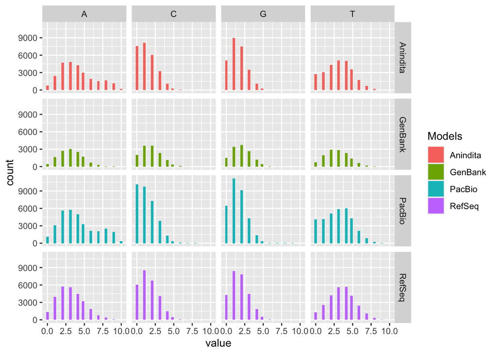

```r
require(Biostrings)
require(Rsamtools)
allstringtie_Transcripts <- transcripts(LongStringtie_txdb)

genome <- FaFile("Genome/GenBank.fa")
genomeLevel <- seqlengths(genome)
genomeRanges <- GRanges(names(genomeLevel),IRanges(1,genomeLevel))
genomeFreq <- alphabetFrequency(readDNAStringSet("Genome/GenBank.fa"))

# allBRCDK_Transcripts <- allBRCDK_Transcripts[seqnames(allBRCDK_Transcripts) %in% names(genomeLevel)]
# allBRCDK_Transcripts[]
PacBioStringtie_20tails <- flank(allstringtie_Transcripts,start=FALSE,width = 10)
PacBioStringtie_20tails <- PacBioStringtie_20tails[findOverlaps(PacBioStringtie_20tails,genomeRanges,type = "within")@from %>% unique]
PacBioStringtie_20tailSeqs <- getSeq(genome,PacBioStringtie_20tails)
names(PacBioStringtie_20tailSeqs) <- PacBioStringtie_20tails$tx_name
PacBioStringtie_20AF <- alphabetFrequency(PacBioStringtie_20tailSeqs)
rownames(PacBioStringtie_20AF) <-PacBioStringtie_20tails$tx_name

polyA <- ifelse((vcountPattern("AAAAAA",PacBioStringtie_20tailSeqs) > 0),6,
        ifelse((vcountPattern("AAAAA",PacBioStringtie_20tailSeqs) > 0),5,
            ifelse((vcountPattern("AAAA",PacBioStringtie_20tailSeqs) > 0),4,0)))

PacBioStringtie_20AF <- PacBioStringtie_20AF %>% as.data.frame %>% mutate(polyA=polyA)

PBani_GTF <- import("~/Downloads/Anindita_stringtie/Stringtie_Sample1.gtf")
PBani_GTF <- PBani_GTF[strand(PBani_GTF) != "*"]

PBani_txdb <- makeTxDbFromGRanges(PBani_GTF)
PBani_Transcripts <- transcripts(PBani_txdb)
PBani_20tails <- flank(PBani_Transcripts,start=FALSE,width = 10)
PBani_20tails <-PBani_20tails[findOverlaps(PBani_20tails,genomeRanges,type = "within")@from %>% unique]
PBani_20tailSeqs <- getSeq(genome,PBani_20tails)
names(PBani_20tailSeqs) <-PBani_20tails$tx_name
PBani_20AF <- alphabetFrequency(PBani_20tailSeqs)
rownames(PBani_20AF) <-PBani_20tails$tx_name

polyA <- ifelse((vcountPattern("AAAAAA",PBani_20tailSeqs) > 0),6,
        ifelse((vcountPattern("AAAAA",PBani_20tailSeqs) > 0),5,
            ifelse((vcountPattern("AAAA",PBani_20tailSeqs) > 0),4,0)))

PBani_20AF <- PBani_20AF %>% as.data.frame %>% mutate(polyA=polyA)

require(Biostrings)
require(Rsamtools)
BRCDK_Transcripts <- transcripts(BRCDK_txdb)

BRCDK_20tails <- flank(BRCDK_Transcripts,start=FALSE,width = 10)
BRCDK_20tails <- BRCDK_20tails[findOverlaps(BRCDK_20tails,genomeRanges,type = "within")@from %>% unique]
BRCDK_20tailSeqs <- getSeq(genome,BRCDK_20tails)
names(BRCDK_20tailSeqs) <- BRCDK_20tails$tx_name
BRCDK_20AF <- alphabetFrequency(BRCDK_20tailSeqs)
rownames(BRCDK_20AF) <-BRCDK_20tails$tx_name


polyA <- ifelse((vcountPattern("AAAAAA",BRCDK_20tailSeqs) > 0),6,
        ifelse((vcountPattern("AAAAA",BRCDK_20tailSeqs) > 0),5,
            ifelse((vcountPattern("AAAA",BRCDK_20tailSeqs) > 0),4,0)))

BRCDK_20AF <- BRCDK_20AF %>% as.data.frame %>% mutate(polyA=polyA)



require(Biostrings)
require(Rsamtools)
RefSeq_Transcripts <- transcripts(RefSeq_txdb)

RefSeq_20tails <- flank(RefSeq_Transcripts,start=FALSE,width = 10)
RefSeq_20tails <- RefSeq_20tails[findOverlaps(RefSeq_20tails,genomeRanges,type = "within")@from %>% unique]
RefSeq_20tailSeqs <- getSeq(genome,RefSeq_20tails)
names(RefSeq_20tailSeqs) <- RefSeq_20tails$tx_name
RefSeq_20AF <- alphabetFrequency(RefSeq_20tailSeqs)
rownames(RefSeq_20AF) <-RefSeq_20tails$tx_name

polyA <- ifelse((vcountPattern("AAAAAA",RefSeq_20tailSeqs) > 0),6,
        ifelse((vcountPattern("AAAAA",RefSeq_20tailSeqs) > 0),5,
            ifelse((vcountPattern("AAAA",RefSeq_20tailSeqs) > 0),4,0)))

RefSeq_20AF <- RefSeq_20AF %>% as.data.frame %>% mutate(polyA=polyA)





require(Biostrings)
require(Rsamtools)
GenBank_Transcripts <- transcripts(GenBank_txdb)

GenBank_20tails <- flank(GenBank_Transcripts,start=FALSE,width = 10)
GenBank_20tails <- GenBank_20tails[findOverlaps(GenBank_20tails,genomeRanges,type = "within")@from %>% unique]
GenBank_20tailSeqs <- getSeq(genome,GenBank_20tails)
names(GenBank_20tailSeqs) <- GenBank_20tails$tx_name
GenBank_20AF <- alphabetFrequency(GenBank_20tailSeqs)
rownames(GenBank_20AF) <-GenBank_20tails$tx_name

polyA <- ifelse((vcountPattern("AAAAAA",GenBank_20tailSeqs) > 0),6,
        ifelse((vcountPattern("AAAAA",GenBank_20tailSeqs) > 0),5,
            ifelse((vcountPattern("AAAA",GenBank_20tailSeqs) > 0),4,0)))

GenBank_20AF <- GenBank_20AF %>% as.data.frame %>% mutate(polyA=polyA)


PBLong <- PacBioStringtie_20AF %>%
 as.data.frame() %>%
 select(A,G,C,T,polyA) %>%
 pivot_longer(cols = !matches("poly")) %>%
 mutate(Models="PacBio")
GBLong <- GenBank_20AF %>%
 as.data.frame() %>%
 select(A,G,C,T,polyA) %>%
 pivot_longer(cols = !matches("poly")) %>%
 mutate(Models="GenBank")
RefSeqLong <- RefSeq_20AF %>%
 as.data.frame() %>%
 select(A,G,C,T,polyA) %>%
 pivot_longer(cols = !matches("poly")) %>%
 mutate(Models="RefSeq")
PBaniLong <- PBani_20AF %>%
 as.data.frame() %>%
 select(A,G,C,T,polyA) %>%
 pivot_longer(cols = !matches("poly")) %>%
 mutate(Models="Anindita")

toPlot <- rbind(PBLong,PBaniLong,GBLong,RefSeqLong)

ggplot(toPlot,aes(x=value,fill=Models))+
 geom_histogram()+
 facet_grid(Models~name)
```

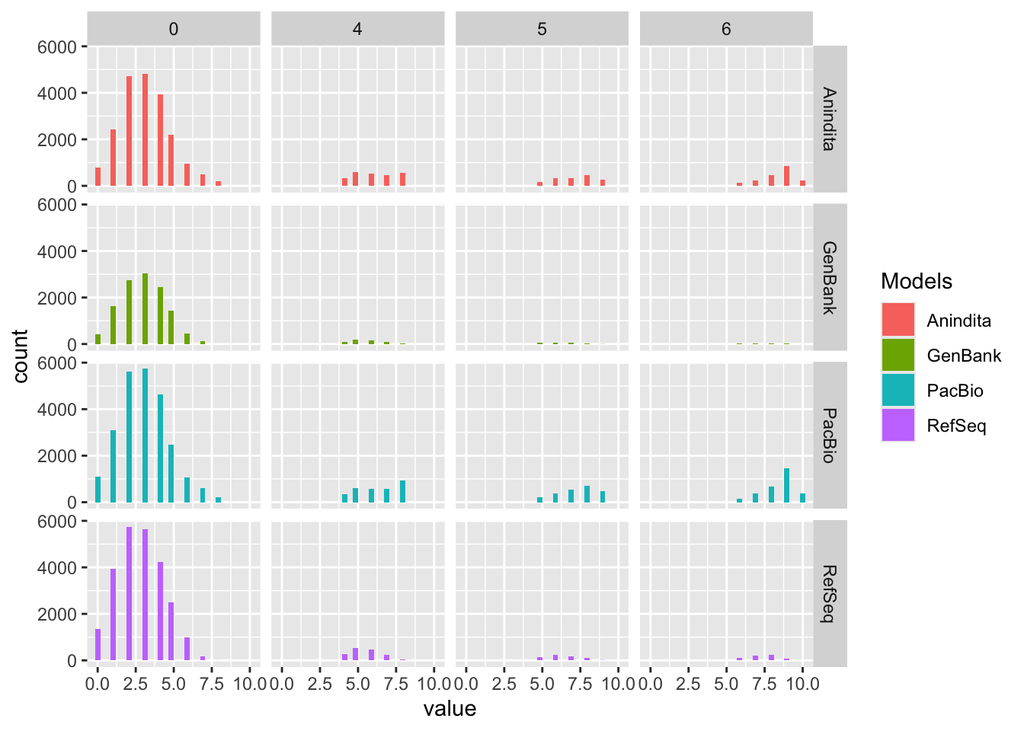

```r
ggplot(toPlot %>% filter(name=="A"),
    aes(x=value,fill=Models))+
 geom_histogram()+
 facet_grid(Models~polyA)
```

```r
potentialPolyFakes <- PacBioStringtie_20AF[(PacBioStringtie_20AF$polyA ==4 & PacBioStringtie_20AF$A >= 7) | (PacBioStringtie_20AF$polyA > 4),]

potentialPolyFakeGenes <- rownames(potentialPolyFakes) %>% unique %>% gsub("\\.\\d+$","",.)
```